# R Notebook

# Learning in high dimensions

## Mixture of PPCA and HDDC

The two methods are available in the HDclassif package:

```r
#install.packages('HDclassif')
library(HDclassif)
```

The package contains two main functions:

- `hddc` which allows to cluster high-dimensional data,
- `hdda` for the supervised classification of HD data.

Let’s first focus on the *supervised classification problem*, and let’s compare hdda with LDA and SVM for instance. Let’s first load some HD data from the `MBCbook` package:

```r
#install.packages('MBCbook')
library(MBCbook)
data("usps358")
```

These data are vectorized version of handwritten digits provided by the U.S. Post Service. It is possible to visualize the 16x16 images as follows:

```r
X = usps358[,-1]
cls = usps358$cls

# Visulise some of the digits:
par(mfrow = c(1,4))
imshow(matrix(t(X[134,]),nrow = 16,byrow = TRUE))
imshow(matrix(t(X[1278,]),nrow = 16,byrow = TRUE))
```

[figure not shown]

```r
imshow(matrix(t(X[564,]),nrow = 16,byrow = TRUE))
imshow(matrix(t(X[869,]),nrow = 16,byrow = TRUE))
```

A basic call of hdda is as follows:

```r
learn = sample(1:nrow(X),1500)
f = hdda(X[learn,],cls[learn])
Yhat = predict(f,X[-learn,])
err.hdda = sum(Yhat$class != cls[-learn]) / length(Yhat$class)
err.hdda
```

```
[1] 0.03515625
```

Here, because we have a fitted GMM, we can have a look at the model parameters:

```r
# the class-specific dimensionalities
f$d
```

```
      Intrinsic dimensions of the classes:
       1 2 3
  dim: 7 7 4
```

```r
# The variance of the data within the class-specific subspaces
f$a
```

```
     Akj:
Class   a1    a2   a3   a4   a5   a6   a7
    1 11.2  7.89 7.11 6.52 5.21 3.97 3.69
    2 14.2 10.10 8.69 7.31 5.75 4.41 4.34
    3 12.9  7.95 6.58 5.69    .    .    .
```

```r
# The variance of the noise ouside the subspaces
f$b
```

```
        1     2     3
Bk: 0.179 0.203 0.221
```

It is of course possible to look at the means as average digits:

```r
par(mfrow = c(1,3))
imshow(matrix(t(f$mu[1,]),nrow = 16,byrow = TRUE))
imshow(matrix(t(f$mu[2,]),nrow = 16,byrow = TRUE))
```

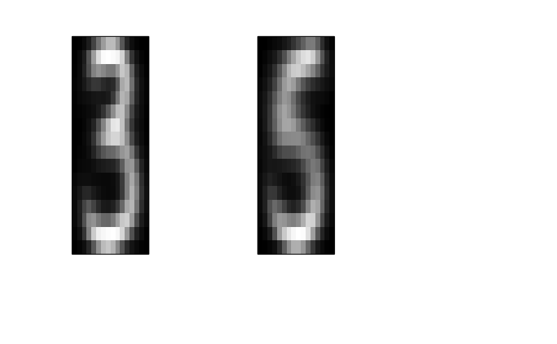

```r
imshow(matrix(t(f$mu[3,]),nrow = 16,byrow = TRUE))
```

> Exercise: look at the effect of varying the threshold $\tau$ on the classification error.

```r
tau = seq(200, 1,by = -10) / 1000
err = matrix(NA,10,20)
for (i in 1:10){cat('.')
  learn = sample(1:nrow(X),1500)
  for (j in 1:length(tau)){
    f = hdda(X[learn,],cls[learn],threshold = tau[j])
    Yhat = predict(f,X[-learn,])
    err[i,j] = sum(Yhat$class != cls[-learn]) / length(Yhat$class)
  }
}
```

```
..........
```

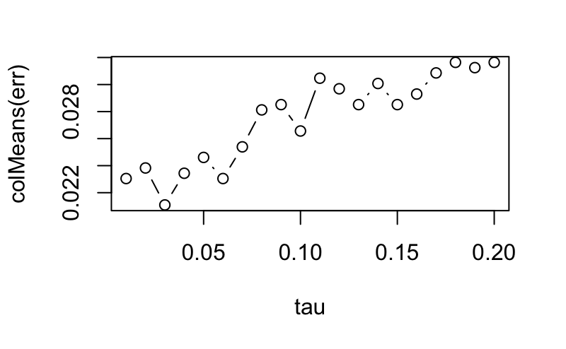

```r
plot(tau,colMeans(err),type='b')
```

In fact, hdda implements an internal CV for selecting the best $\tau$ for the data at hand:

```r
learn = sample(1:nrow(X),1500)
f = hdda(X[learn,],cls[learn],d_select="CV",
         cv.threshold = c(0.2,0.1,0.05,0.01,0.005,0.001))
Yhat = predict(f,X[-learn,])
err.hdda = sum(Yhat$class != cls[-learn]) / length(Yhat$class)
err.hdda
```

```
[1] 0.03125
```

> Exercise: compare HDDA with LDA on this data set.

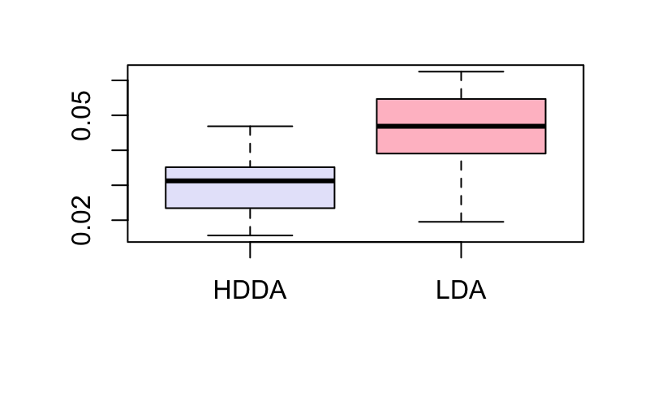

```r
err = matrix(NA,2,25)
for(i in 1:25){
  learn = sample(1:nrow(X),1500)
  f = hdda(X[learn,],cls[learn],d_select="CV",
         cv.threshold = c(0.2,0.1,0.05,0.01,0.005,0.001))
  Yhat = predict(f,X[-learn,])
  err[1,i] = sum(Yhat$class != cls[-learn]) / length(Yhat$class)

  g = lda(X[learn,],cls[learn])
  Yhat = predict(g,X[-learn,])
  err[2,i] = sum(Yhat$class != cls[-learn]) / length(Yhat$class)
}
boxplot(t(err),names=c('HDDA','LDA'),col=c('lavender','pink'))
```

Let’s now move to the *clustering problem*:

```r
data("usps358")
X = usps358[,-1]
cls = usps358$cls

out = hddc(X,K = 3)

table(cls, out$class)
```

```
cls   1   2   3
  1  45  20 593
  2 550   2   4
  3  22 494  26
```

Of course, we can here also visualize the group means to understand the average individual of each group:

```r
par(mfrow = c(1,3))
imshow(matrix(t(out$mu[1,]),nrow = 16,byrow = TRUE))
imshow(matrix(t(out$mu[2,]),nrow = 16,byrow = TRUE))
```

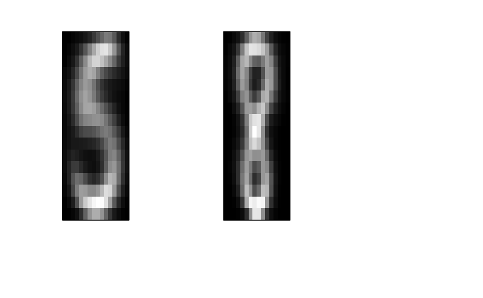

```r
imshow(matrix(t(out$mu[3,]),nrow = 16,byrow = TRUE))
```

> Exercise: compare the clustering results of HDDC and Mclust.

> Exercise: use BIC to select both the appropriate HDDC submodel and the value of K.